# data_cleaning Grand Falls

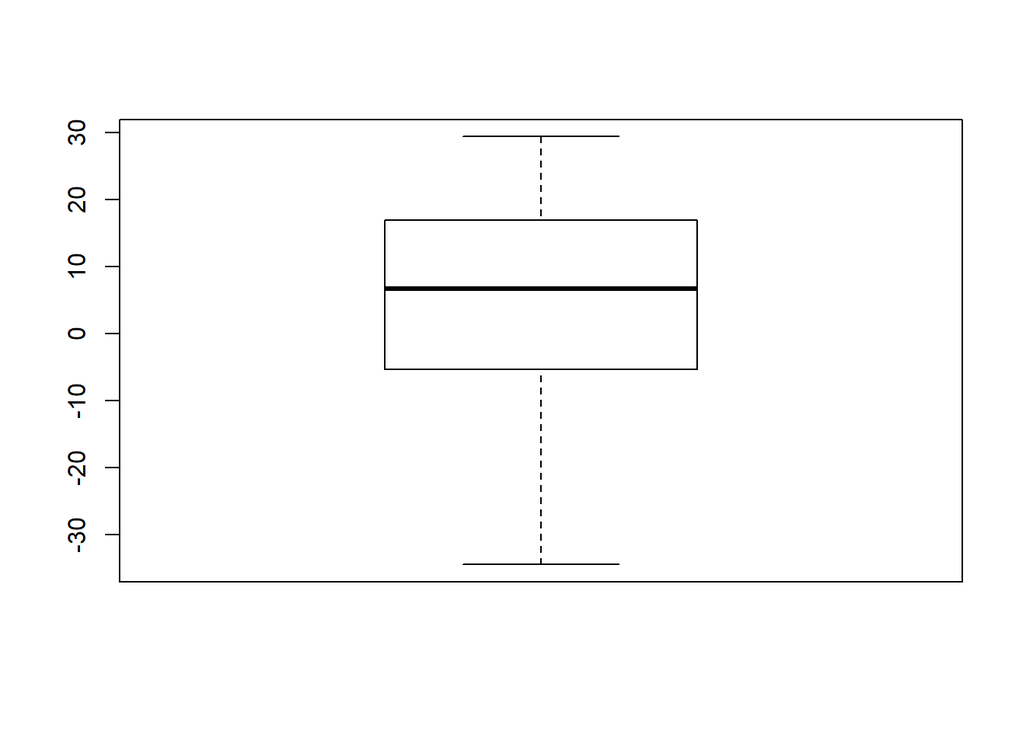

```r
boxplot(meteo_grand$Avg.Temp)
```

some temperatures have been estimated

- rainfall outliers

```r
# Rainfall
zScores_rainfall_grand <- (meteo_grand$Rainfall - mean(meteo_grand$Rainfall, na.rm = T)) / sd(meteo_grand$Rainfall, na.rm = T)
sum(abs(zScores_rainfall_grand)> 3.29, na.rm = TRUE)
```

```
## [1] 86
```

```r
sum(is.na(meteo_grand$Rainfall))
```

```
## [1] 3198
```

```r
sum(meteo_grand["Rainfall.Flag"]=="E", na.rm = TRUE)
```

```
## [1] 78
```

```r
sum(meteo_grand["Rainfall.Flag"]=="M", na.rm = TRUE)
```

```
## [1] 3198
```

The histogram is highly skewed right.

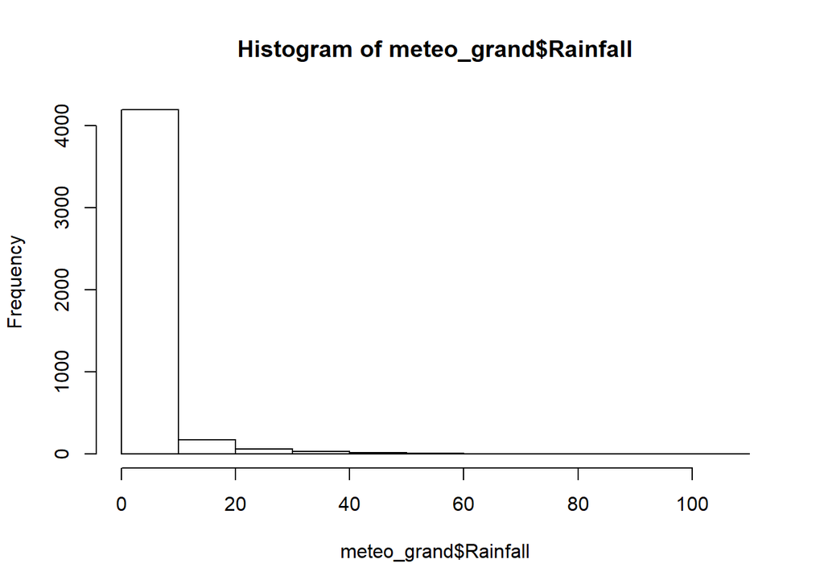

```r
hist(meteo_grand$Rainfall)
```

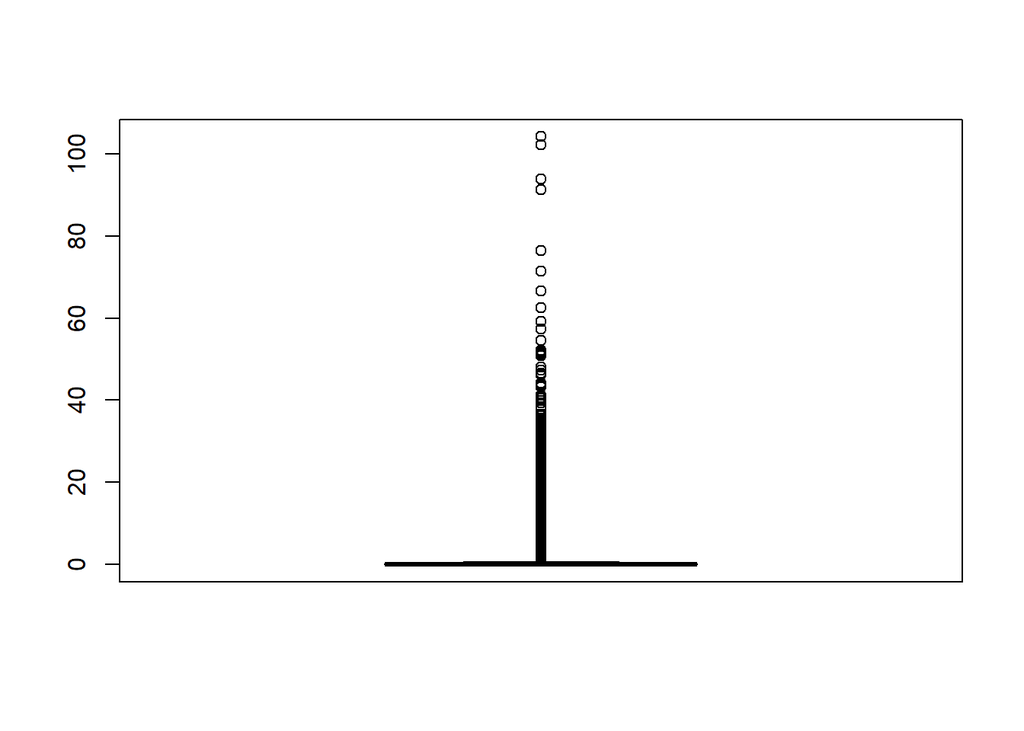

```r
boxplot(meteo_grand$Rainfall)
```

- Penman PET (in mm)

```r
# Penman
zScores_penman_grand <- (meteo_grand$Penman.PET - mean(meteo_grand$Penman.PET, na.rm = T)) / sd(meteo_grand$Penman.PET, na.rm = T)
sum(abs(zScores_penman_grand)> 3.29, na.rm = TRUE)
```

```
## [1] 17
```

Also the histogram of Penman is skewed right.

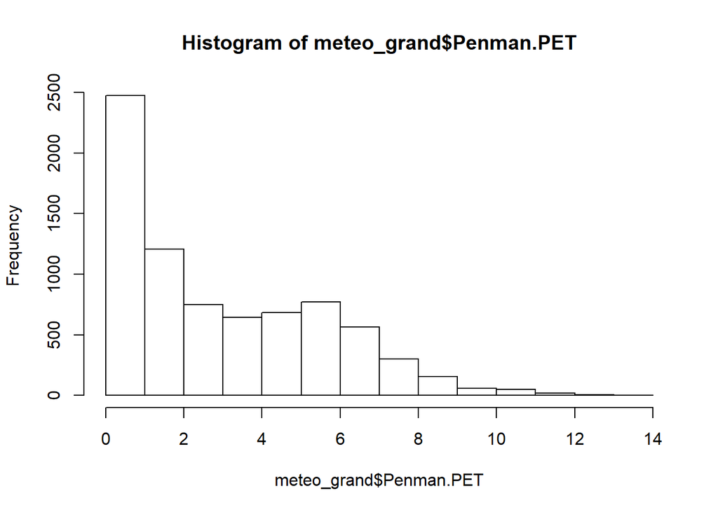

```r
hist(meteo_grand$Penman.PET)
```

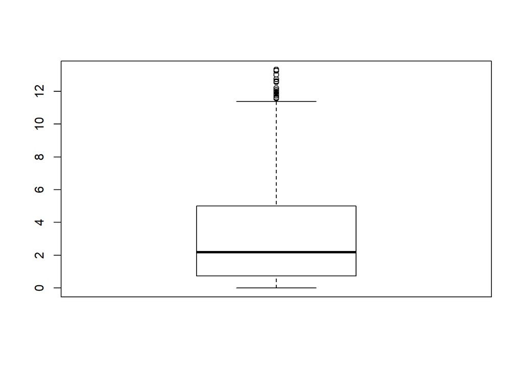

```r
boxplot(meteo_grand$Penman.PET)
```

**Bivariate Outliers** We are going to use scatter plots and mahalanobis distance.

- Average Temperature with Rainfall

```r
mahaDistance = mahalanobis(cbind(meteo_grand$Avg.Temp, meteo_grand$Rainfall), center = c(mean(meteo_grand$Avg.Temp, na.rm = T), mean(meteo_grand$Rainfall, na.rm = T)),cov = cov(cbind(meteo_grand$Avg.Temp, meteo_grand$Rainfall), use = "complete.obs"))

#mahaDistance
sum(pchisq(q = mahaDistance, df = 1, lower.tail = FALSE) >= 0.05, na.rm = T)
```

```
## [1] 2898
```

```r
leverage = mahaDistance / (nrow(meteo_grand) -1) + 1 / nrow(meteo_grand)

sum(leverage > mean(leverage)*3, na.rm = T)
```

```
## [1] 0
```

- Average Temperature with Penman.PET

```r
mahaDistance = mahalanobis(cbind(meteo_grand$Avg.Temp, meteo_grand$Penman.PET), center = c(mean(meteo_grand$Avg.Temp, na.rm = T), mean(meteo_grand$Penman.PET, na.rm = T)),cov = cov(cbind(meteo_grand$Avg.Temp, meteo_grand$Penman.PET), use = "complete.obs"))

#mahaDistance
sum(pchisq(q = mahaDistance, df = 1, lower.tail = FALSE) >= 0.05, na.rm = T)
```

```
## [1] 6719
```

```r
leverage = mahaDistance / (nrow(meteo_grand) -1) + 1 / nrow(meteo_grand)

sum(leverage > mean(leverage)*3, na.rm = T)
```

```
## [1] 137
```

- Rainfall with Penman.PET

```r
mahaDistance = mahalanobis(cbind(meteo_grand$Rainfall, meteo_grand$Penman.PET), center = c(mean(meteo_grand$Rainfall, na.rm = T), mean(meteo_grand$Penman.PET, na.rm = T)),cov = cov(cbind(meteo_grand$Rainfall, meteo_grand$Penman.PET), use = "complete.obs"))

#mahaDistance
sum(pchisq(q = mahaDistance, df = 1, lower.tail = FALSE) >= 0.05, na.rm = T)
```

```
## [1] 3877
```

```r
leverage = mahaDistance / (nrow(meteo_grand) -1) + 1 / nrow(meteo_grand)

sum(leverage > mean(leverage)*3, na.rm = T)
```

```
## [1] 0
```

- Rainfall with Penman.PET and Temperature

```r
mahaDistance = mahalanobis(cbind(meteo_grand$Rainfall, meteo_grand$Penman.PET, meteo_grand$Avg.Temp), center = c(mean(meteo_grand$Rainfall, na.rm = T), mean(meteo_grand$Penman.PET, na.rm = T), mean(meteo_grand$Avg.Temp, na.rm = T)),cov = cov(cbind(meteo_grand$Rainfall, meteo_grand$Penman.PET, meteo_grand$Avg.Temp), use = "complete.obs"))

#mahaDistance
sum(pchisq(q = mahaDistance, df = 2, lower.tail = FALSE) >= 0.05, na.rm = T)
```

```
## [1] 3381
```

```r
leverage = mahaDistance / (nrow(meteo_grand) -1) + 1 / nrow(meteo_grand)

sum(leverage > mean(leverage)*3, na.rm = T)
```

```
## [1] 0
```

- Every variable for finding bivariate outliers

```r
n = ncol(meteo_grand)

#for(j in 1:(n-1)){
#    for(i in 1:(n-j)){

      # print name of variable
      #print(c(colnames(meteo_grand[i]), colnames(meteo_grand[j])))


      # Calculate mahaDistance
      #mahaDistance = mahalanobis(cbind(meteo_grand[,i], meteo_grand[,j]), center = c(mean(meteo_grand[,i], na.rm = T), mean(meteo_grand[,j], na.rm = T)),cov = cov(cbind(meteo_grand[,i], meteo_grand[,j]), use = "pairwise.complete.obs"))

      #sum(pchisq(q = mahaDistance, df = 1, lower.tail = FALSE) >= 0.05, na.rm = T)



      # Calculate leverage
      #leverage = mahaDistance / (nrow(meteo_grand) -1) + 1 / nrow(meteo_grand)

      #sum(leverage > mean(leverage)*3, na.rm = T)
  #}
#}

#for (i in 1:12) {
  #for (j in (i+1):13) {
    #print(c(i,j))

    #mahaDistance = mahalanobis(cbind(meteo_grand[,i], meteo_grand[,j]), center = c(mean(meteo_grand[,i], na.rm = T), mean(meteo_grand[,j], na.rm = T)),cov = cov(cbind(meteo_grand[,i], meteo_grand[,j]), use = "pairwise.complete.obs"))

  #}
#}
```

**Skewness and kurtosis**

```r
require(moments)
# for average temperature
skewness(meteo_grand$Avg.Temp)
```

```
## [1] -0.3997648
```

```r
kurtosis(meteo_grand$Avg.Temp)
```

```
## [1] 2.146122
```

```r
pnorm(q =  (skewness(meteo_grand$Avg.Temp) - 0) / sqrt(6 / length(meteo_grand$Avg.Temp)), lower.tail = FALSE)
```

```
## [1] 1
```

```r
pnorm(q =  (kurtosis(meteo_grand$Avg.Temp) - 0) / sqrt(24 / length(meteo_grand$Avg.Temp)), lower.tail = FALSE)
```

```
## [1] 0
```

```r
# for rainfall
skewness(meteo_grand$Rainfall, na.rm = T)
```

```
## [1] 6.214974
```

```r
kurtosis(meteo_grand$Rainfall, na.rm = T)
```

```
## [1] 58.20437
```

```r
pnorm(q =  (skewness(meteo_grand$Rainfall, na.rm = T) - 0) / sqrt(6 / length(meteo_grand$Rainfall)), lower.tail = F)
```

```
## [1] 0
```

```r
pnorm(q =  (kurtosis(meteo_grand$Rainfall, na.rm = T) - 0) / sqrt(24 / length(meteo_grand$Rainfall)), lower.tail = F)
```

```
## [1] 0
```

```r
# for penman.PET
skewness(meteo_grand$Penman.PET)
```

```
## [1] 0.7902166
```

```r
kurtosis(meteo_grand$Penman.PET)
```

```
## [1] 2.783976
```

```r
pnorm(q =  (skewness(meteo_grand$Penman.PET) - 0) / sqrt(6 / length(meteo_grand$Penman.PET)), lower.tail = FALSE)
```

```
## [1] 2.972244e-176
```

```r
pnorm(q =  (kurtosis(meteo_grand$Penman.PET) - 0) / sqrt(24 / length(meteo_grand$Penman.PET)), lower.tail = FALSE)
```

```
## [1] 0
```

**Bivariate homoscedasticity** scatter plots are usually enough

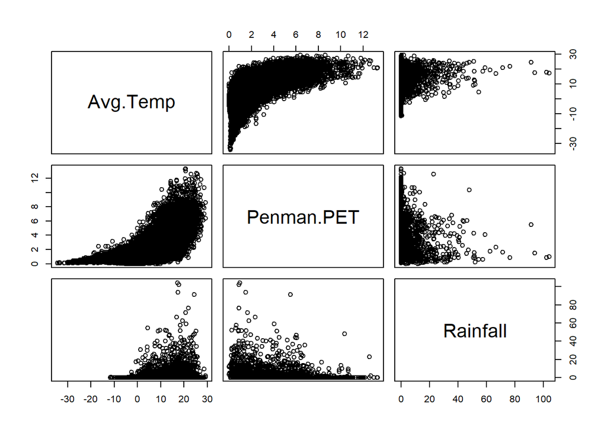

```r
pairs(meteo_grand[,c(8,10,12)])
```

**Bivariate linearity** use a qq-plot, it’s a bit cleaner than just an outright scatterplot - and be ready to transform anything that isn’t linear

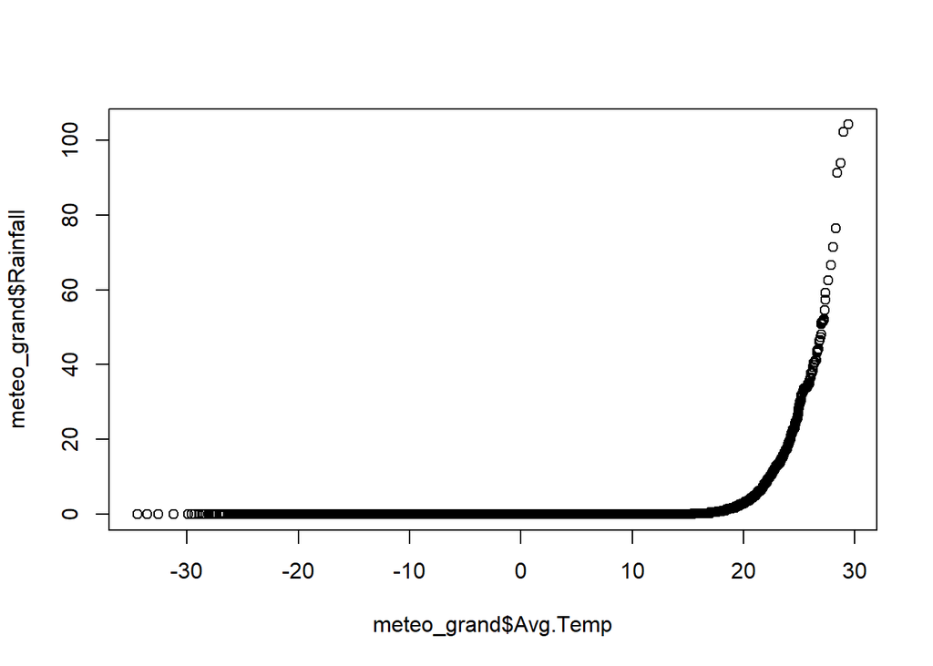

```r
qqplot(meteo_grand$Avg.Temp, meteo_grand$Rainfall)
```

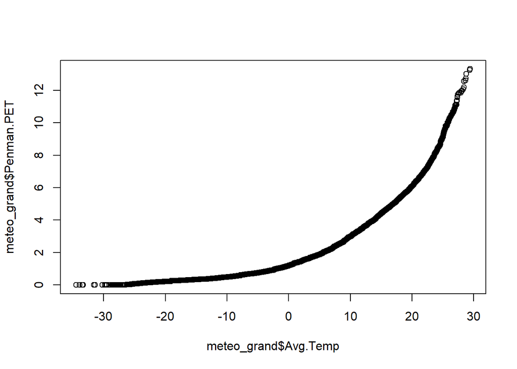

```r
qqplot(meteo_grand$Avg.Temp, meteo_grand$Penman.PET)
```

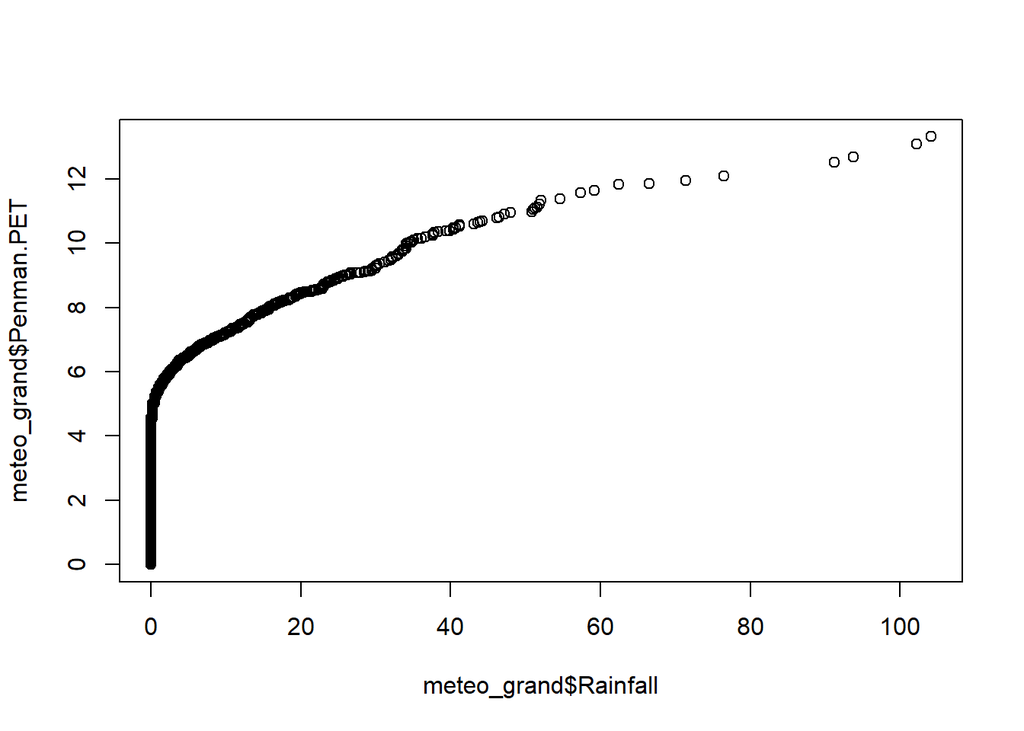

```r
qqplot(meteo_grand$Rainfall, meteo_grand$Penman.PET)
```

**Multicollinearity & Singularity**

```r
corMat_grand = cor(cbind(meteo_grand$Avg.Temp, meteo_grand$Rainfall, meteo_grand$Penman.PET), use = "complete.obs")
corMat_grand
```

```
##            [,1]        [,2]       [,3]
## [1,] 1.00000000  0.07131845  0.5822674
## [2,] 0.07131845  1.00000000 -0.2108876
## [3,] 0.58226745 -0.21088764  1.0000000
```

```r
eig = eigen(corMat_grand)
```

There appears to be no multicollinearity or singularity because none of the correlations are above 0.9.

```r
eig = eigen(corMat_grand)
sqrt(max(eig$values)/eig$values)
```

```
## [1] 1.000000 1.236992 2.122019
```

There appears to be no multicollinearity or singularity because none of the condition indices isabove 30